# R grammar

From the *Introduction to R* lecture series by

Mikko Vihtakari

Researcher, Institute of Marine Research  
mikko.vihtakari@hi.no

04 February, 2020

# Outline

R is a [statistical programming environment](http://www.r-project.org/), and together with its extensions, R enables data manipulation, analysis, graphing and article writing all within the same powerful scientific tool. If used correctly, R can save weeks of tedious data handling compared to a commonly used alternative. Learning R, however, can be a daunting task. **The introduction to R** course framework developed by Dr. Mikko Vihtakari consists of *one-day-long courses* that build upon each other. These courses can be offered flexibly tailored to the needs of the audience.

This is a handout for R grammar, the first course in the series. The handout can be freely distributed. You can order the author to give any parts of these lectures or other tailored workshops to your institute. The course consists of four lectures:

1. Getting started with R. Fundamental introduction to R. Consists of a slideshow and the material found from this document.
2. Programming with R I. Teaches you the fundaments of the R language.
3. Programming with R II. Teaches you the data structures in R.
4. Basic data manipulation. Teaches you how to apply the fundaments to simple data manipulation.

**Course description:** R is a widely used open-source statistical programming language. Like any language, R has a set of grammatic rules and exceptions that users have to learn in order to efficiently use R based applications in their work. During this one-day long course, you will get an introduction to the grammar of R and will learn the means to read and understand standard R code. The course goes through R fundaments such as searching for help, operators, objects, vector classes, data types and how to manipulate them using vectors. The course is a good start for anyone new to programming or R. It is also aimed for people who have worked with R for some time but struggle to understand the fundaments behind their code.

# Lecture 1: Getting started with R

## [The R project for statistical computing](http://www.r-project.org/)

- Based on S language
- A highly flexible language and programming environment for statistical computing and graphical techniques
- Open Source, pros, and cons
  - Active community: knowledge and skills from a wide variety of users
  - Free to use anywhere, on any platform (works on Windows OS, OS X and on any Linux distribution), by anyone.
  - Lot’s of help available
  - Produces great looking graphics, if you know what you’re doing
  - You can make your programs
  - Adapted to almost anything
  - Rapid development cycle. Update client does not exist
  - Difficult to use? At least difficult to get started with
  - Often fairly confusing
- Learn more from Wikipedia

A common misconception: “I can’t do it with R”. Sure you can. R does virtually anything, but sometimes you might need to hack a little bit.

Another one: “R is slow for large datasets”. R is not any slower than other commonly used alternatives that are based on interpreted languages (Matlab, Python, …), but every programming language has its weaknesses. These weaknesses are not always similar among languages. In the case of R, the misconception often arises from the [use of loops](https://stackoverflow.com/questions/7142767/why-are-loops-slow-in-r). Use the strengths of R instead of weaknesses, and your code will be processed much faster.

## Installation

Download and install R at https://cran.uib.no/.

**Windows**: *Download R for Windows* $\rightarrow$ *base* $\rightarrow$ *Download R 3.X.X for Windows*. If you have administrator rights, run the installation program as an administrator (right-click the file). This will create R folder in *Program Files* and makes it slightly easier to update the program. If you have an institute computer, install the program without administrator rights. This will create R folder in your folder in *Documents and Settings*. The program works like that too.

**OS X**: *Download R for (Mac) OS X* $\rightarrow$ *R-3.X.X.pkg*.

Installation of R studio

**Warning**: R is a powerful program, which can delete, install, rename, modify and move files on your computer. This kind of program can also download viruses or modify essential operating system files. Therefore, you should exercise caution whenever working with R. Think before you take random R codes from the internet. The R help library files and this document should be safe to use, though.

## R Studio - an improved user interface

R Studio offers an interface that is superior to the standard R interface. Besides, R Studio makes advanced R features such as writing packages and documents, as well as debugging easier. I recommend [installing RStudio](https://www.rstudio.com/products/rstudio/download3/) after you have installed R and following the exercises using R Studio.

### Open R

After you have managed to install R and R Studio, it’s time to open them (**Windows 10**: press WIN and type *‘RS’*, **OS X**: press COMMAND + SPACE and type *‘RS’*). This will open the *R Studio* for you. R Studio is just an interface that you use to run R. From now on all keyboard shortcuts are defined for Windows. Mac users, use *CMD* instead of *CTRL*.

## Elements of R interface

R consists of a *console*, a *script editor* and a *plot window* (Figure 1). R Studio adds more elements such as a *workspace overview window* and a possibility to define *projects*.

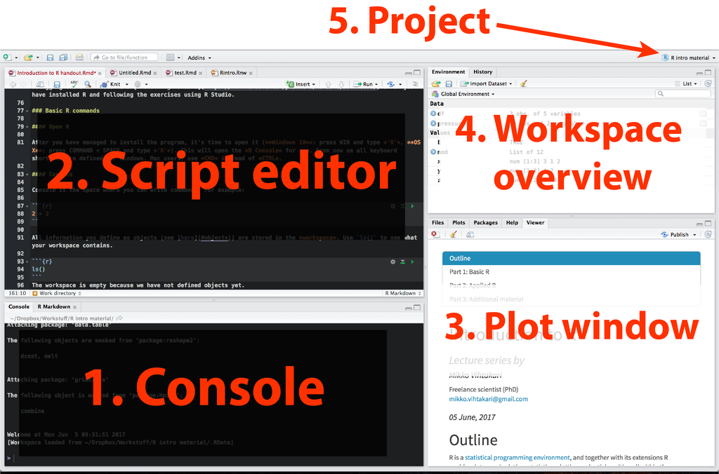

Figure 1: Basic elements of R Studio interface: 1) The console where you can write commands; 2) The script editor where you can save commands to a script for later use; 3) The plot and help file window; 4) The workspace overview and history; and 5) the menu for projects. Colors may differ depending on R Studio settings.

### Customizing RStudio

RStudio comes with reasonable default settings. Nevertheless, there are some things that you might want to change before you start. These include enabling *Soft-wrap R source files* (Tools $\rightarrow$ Global options… $\rightarrow$ Code $\rightarrow$ Editing, General), *Ctrl + Enter executes: Current line* (Code $\rightarrow$ Editing, Execution), *Highlight R function calls* (Code $\rightarrow$ Display), and the *color theme* (Appearance $\rightarrow$ Editor theme). You can [see here](https://support.rstudio.com/hc/en-us/articles/200549016-Customizing-RStudio) how to customize R studio and change settings to your liking.

### Console

Console is like a calculator. You can write commands here (1 in Figure 1). For example:

```r
2 + 2
```

```
## [1] 4
```

All information you define as objects is stored in the *workspace*. Use `ls()` to see what your workspace contains.

```r
ls()
```

```
## character(0)
```

The workspace is empty because we have not defined objects yet. You can also see what your workspace contains in the *workspace overview window* (4 in Figure 1).

### The script editor

The script editor is like a text editor. It is separate from the console and only contains text. R will not evaluate the commands you write to the script editor unless you ask it to do so. Click *File* $\rightarrow$ *New File* $\rightarrow$ *R Script* (or *SHIFT + CTRL + N*). You can now write a script to the editor and send it to R console by pressing *CTRL + R*. You can save the script and open it later. Use the script editor during this course, so that you can look at the scripts again once the course is finished. Use # to make comments in the scripts. Remember to save often (*CTRL + S*). Computers tend to crash. R is not an exception.

### Work directory and projects

Your workspace is set to a default work directory. You find your work directory by the `getwd()` command:

```r
getwd()
## [1] "/Users"
```

R Studio allows the usage of projects (5 in Figure 1). A project automatically defines your work directory to the corresponding project folder.

#### Work directory structure

R will try to open any files from your work directory. It is advised to create a project folder for R scripts that are connected to one project (manuscript, thesis, field campaign). Keeping your R files organized from the beginning will save your time making it possible to find stuff later.

[figure not shown]

Figure 2: Example for structuring your project folder. Code files are neatly numbered and can be sorted. General definitions are placed in the ‘run first’ file that is sourced at the beginning of each R code file. Raw data, modified data and figure files are placed in separate folders.

As a practice, *create a project for this R class* naming the project such that you will remember it years later.

#### `setwd()` and directory separator

You can set your workspace manually. Note that the *directory separator* in R is `/` or `\\` not `\` as in Windows (Mac users ignore this).

```r
setwd("C:/Users/") # Replace the path with your own
setwd("C:\\Users\\") # \\ also works on Windows. Unix users can use the OS default
```

Copy *Introduction to R course script.r* and *example.txt* files in your project directory. Open the R script and append it as we go through this document. Press *CTRL + R* to send a line on the script into the workspace.

#### Clear workspace

At times you might want to clear your work space:

```r
rm(list = ls(all.names = TRUE))
```

## Learn to search for help (you’ll need it)

Since R is an open-source application, there are several ways asking for help. The easiest way to search for help is **R’s helpsheet library**. These help sheets are written in a standard format. The format might feel a bit awkward at first but is very quick to read once you’ve got used to it (analogous to the format of scientific articles).

### Help sheets

A help sheet for a specific command (`plot()` in this case).

```r
?plot # Equivalent to command: help("plot")
```

Search from the help sheet library, if you’re not quite sure about the command, but you know what you’re looking for.

```r
??plot # Equivalent to command: help.search("plot")
```

A help sheet library for a specific package.

```r
help(package = "graphics")
```

Help sheet for the `help()` function.

```r
?help
```

### Google and StackExchange

If you can’t find desired help from the R help sheet library, try **Google**. An active community is one of the blessings of the open-source. It takes a while to learn to Google R help efficiently, but a good starting point is either [R “search word”](http://www.google.com/search?q=r+plotting) or [“search word” with R](http://www.google.com/search?q=plotting+with+r).

If you have been googling for ages, are pretty sure that no-one has answered your question and you *really* need to get an answer, the last hope is either to ask your **colleague** or to use online **discussion forums**. The first option might be a preferred one for beginners, but once you are doing a bit more advanced stuff, you might as well try the latter one. Your R support personnel are likely to have no clue what you are talking about. The best forum for this kind of question is [**StackOverflow**](http://stackoverflow.com/questions/tagged/r) or if your question includes statistics you might try [**CrossValidated**](https://stats.stackexchange.com). Remember that the [better formulated your question is, the better an answer you will get](http://www.wikihow.com/Ask-a-Question-on-Stack-Overflow). It pays off to use a little bit of your time to formulate your questions in [a right way](https://stackoverflow.com/help/how-to-ask). Ideally, you should include [an example about your data and reproducible simplification of the problem](http://stackoverflow.com/questions/5963269/how-to-make-a-great-r-reproducible-example). `rnorm()` and `runif()` functions are useful in making example data frames.

### Cheatsheets

Cheatsheets, or reference cards, are sheets with compiled R commands that are useful for one specific thing. In general, [RStudio maintains a repository of the best-looking cheat sheets](https://www.rstudio.com/resources/cheatsheets/), but you can also [try your luck with google](http://www.google.com/search?q=r+cheat+sheet). Cheat sheets should not be confused with help sheets.

# Lecture 2: Programming with R I

## Fundaments

### Decimal separator

The **decimal separator** is a period (.) not a comma (,). The comma is used within functions to separate arguments.

```r
4 * c(2,4) + sin(0.3) - exp(5)
```

```
## [1] -140.1176 -132.1176
```

If you use Excel and have a European language as your system language, you will need to [change the system separatator](https://www.howtogeek.com/245510/how-to-change-excels-decimal-separators-from-periods-to-commas/) before you can import data from Excel to R.

### Case sensitivity

R is **case sensitive**, so capital letters in commands do matter. A rather annoying feature of R is that, if you forget something or make a slight mistake when writing commands, the program has no clue what you’re trying to do. Luckily it often specifies which part of the command it didn’t understand. Sometimes you might have several mistakes within a command. R always tells you the first one.

#### Debugging

The following command has several mistakes. Try to correct them one by one until you will get rid of error messages. Press $\uparrow$ to get back to a previous command.

```r
sin(90 + 2*pi()) + Cos(0.3) - exp(0,5)
```

### Commenting

Everything after `#` will not be evaluated by R and is handled as a comment. This is equivalent to `%` sign in Matlab or $\LaTeX$.

```r
1 + 1 # 1 plus 1 is 2, right?
```

```
## [1] 2
```

### Functions

The program consists of functions that will do things for you if you know their name.

```r
sqrt(3) # square root of 3
```

```
## [1] 1.732051
```

You can also define your own functions.

```r
f <- function(x){x^2 + 2*x} # You can calculate virtually anything with R, but sometimes it might look a little bit complicated.
f(2) # However, often it only looks like it
```

```
## [1] 8
```

Function calculated above was $f(x) = x^2 + 2x$ with $x = 2$. You can learn more about writing your own functions later (or see [here](https://nicercode.github.io/guides/functions/), the [official R manual](https://cran.r-project.org/doc/manuals/R-intro.html#Writing-your-own-functions) or [Hadley Wickhams tips](http://adv-r.had.co.nz/Functions.html)).

## Objects

The workflow in R does not involve clicking. Instead, you will need to make **objects**. An object in R can be about anything from a data frame to a vector or a function. The object name can also be anything as long as it starts with a letter and does not include special characters or symbols because these have other meanings in S language. Note that R is **case sensitive**. This means that if you name your object [`GjeddE`](http://no.wikipedia.org/wiki/Gjedde), you will need to call it with the capital letters for the rest of your script. Thus it is recommended to [**use simple, short and descriptive object names**](http://style.tidyverse.org/syntax.html#object-names).

## Operators

Operators are programming language supported primitive commands.

### Assignment operators

Objects are built by assigning values to them. The assignment operator in R is `<-`. Simple equal sign (`=`) also works as an assignment operator, but it has [a different meaning inside function calls](http://stackoverflow.com/questions/1741820/assignment-operators-in-r-and) and therefore usage of `=` is not recommended.

```r
x <- 4 # Assigning value 4 for a vector called 'x'
x = 4 # '=' is analogous to '<-' in this case
sum(x <- 4, na.rm = TRUE) # But not here. Assigning value 4 to x inside a function. 'na.rm =' specifies that the sum function should ignore missing values. See ?sum
```

```
## [1] 4
```

**Alt + -** is the [keyboard shortcut](https://www.howtogeek.com/245510/how-to-change-excels-decimal-separators-from-periods-to-commas/) for the assignment operator in R Studio

Objects can be thought of as advanced equivalents to “memory buttons” in a calculator. In R you just assign a name for each “memory button” press. Once an object has been assigned, R remembers it and you can build new objects from already assigned ones:

```r
x
```

```
## [1] 4
```

```r
y <- x + 3
x + y
```

```
## [1] 11
```

### Arithmetric operators

Here is a short list of **arithmetric** (mathematical) operators in S language:

| - | Minus | / | Division | %% | [Modulus](https://en.wikipedia.org/wiki/Modulo_operation) |
| --- | --- | --- | --- | --- | --- |
| + | Plus | ^ | Exponentiation | %/% | Integer division |
| * | Multiplication | () | Parentheses | %*% | [Matrix multiplication](https://en.wikipedia.org/wiki/Matrix_multiplication) |

R functions as a common calculator. To test whether you understood the arithmetic operators, you can try to type in following statement in R:

$\frac{2}{2-1} \times \frac{3+3}{2} + 2^2 - \sqrt{4}$

If you typed in the statement correctly, you should get the following answer:

```
## [1] 8
```

You can ignore the operators with a link for now. They are meant as later references as you become a more advanced R user.

### Logical operators

[Logical, or boolean, operators](https://en.wikipedia.org/wiki/Boolean_algebra) are operators that return either true or false. Note that in R logical values are always capitalized (i.e. `TRUE` and `FALSE`), and can be abbreviated to `T` and `F`. Abbreviating logical values is not recommended when you are writing functions, but is perfectly acceptable when you write code for yourself.

```r
T # == TRUE
```

```
## [1] TRUE
```

```r
F # == FALSE
```

```
## [1] FALSE
```

```r
try(true) # true in lower case is not a logical operator
```

```
## Error in try(true) : object 'true' not found
```

Here is a list of most common **logical operators** in S language:

| == | Equal to | < | Less than | ! | NOT |
| --- | --- | --- | --- | --- | --- |
| != | Not equal to | <= | Less or equal to | && | [non-vectorized AND](http://stackoverflow.com/questions/6558921/r-boolean-operators-and) |
| > | Greater than | & | AND | \|\| | [non-vectorized OR](http://stackoverflow.com/questions/6558921/r-boolean-operators-and) |
| >= | Greater or equal to | \| | OR |  |  |

To test whether you understood logical operators, try telling R that:

- 1 equals 2
- 1 does not equal 2
- 1 is less than 2
- 1 equals 2 or true equals 1
- 1 equals 2 and true equals 1

You should get following answers:

```
## [1] FALSE
```

```
## [1] TRUE
```

```
## [1] TRUE
```

```
## [1] TRUE
```

```
## [1] FALSE
```

Note how R registers `TRUE` as 1 and `FALSE` as 0:

```r
TRUE == 1
```

```
## [1] TRUE
```

```r
FALSE == 0
```

```
## [1] TRUE
```

```r
TRUE == 1.1
```

```
## [1] FALSE
```

### Other operators

R includes a whole lot of other operators that can be used to subset, comment and control code or ask for help.

| [ ] | Subset | # | Comment | { } | Code chunk |
| --- | --- | --- | --- | --- | --- |
| $ | Subset | %in% | Matching | ? | Help |

Also colon operators:

- `:` Generate regular sequences
- `::` Access an object (function) from a package without importing the package
- `:::` Access an internal (hidden) object (function) from a package

## Vectors

[**Vectors**](http://stackoverflow.com/questions/508374/what-are-vectors-and-how-are-they-used-in-programming) are one of the base elements of computer programming and are the most important [object class](http://stat.ethz.ch/R-manual/R-devel/library/base/html/class.html) in R. Numeric vectors in R behave similarly to vectors in [linear algebra](https://www.khanacademy.org/math/linear-algebra/vectors-and-spaces), where the first number in the vector defines the length along the first (x) axis, the second number along the second axis (y), and so on.

For example, a vector $\mathbf{x} = \langle 4, -3 \rangle$ can be written to R as follows `x <- c(4, -3)`, where `c()` is the function for defining vectors (see `?c`). Note that comma (`,`) is used to separate arguments (values) here. This vector looks as follows:

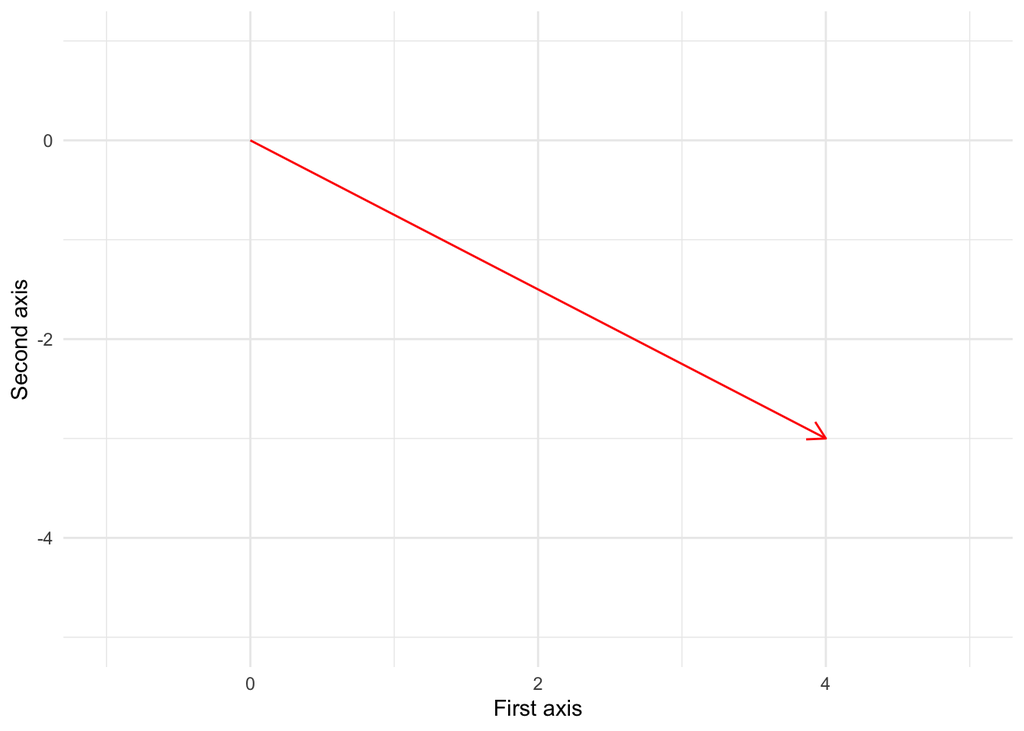

We can define a second vector $\mathbf{y} = \langle 2, 1 \rangle$. Define the vector in R and create a new object z, which is `x - y`. You should get following answer:

```
## [1]  2 -4
```

We see that the first element in `y` (2) was subtracted from the first element in `x` (4) leading to 2. The same calculation was done for the second elements illustrating that vectors in R behave similarly to vectors in linear algebra:

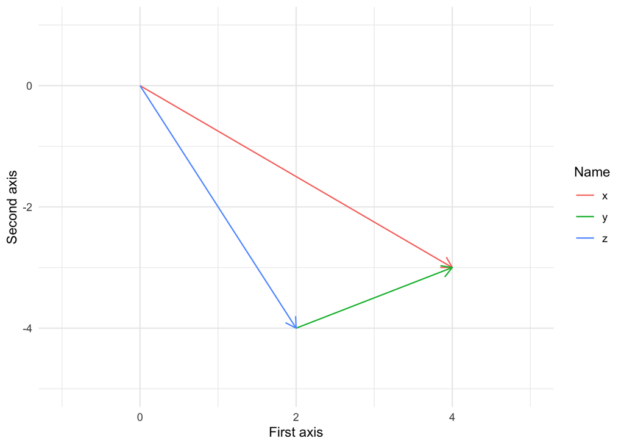

Now that you know this fact, you can ignore the maths and trust that R does vector calculus correctly for you. Instead, you should remember that most things we do with R are essentially based on vectors, which are simply just assemblages of values (numbers, characters, logical operators, objects, etc.). You can add, multiply, subtract or divide vectors to calculate what you need. You should note, however, that when you do calculations with **vectors of different length**, the shorter vector will be reused to compensate the length of the longer one:

```r
x <- c(3, 1, 2)
y <- c(4, 2)
x + y # '4' from y is used twice. R warns you about this.
```

```
## [1] 7 3 6
```

The **repetition of shorter vectors is very useful**, however, when you want to, for example, multiply an entire vector by a scalar (one value):

```r
x * 2
```

```
## [1] 6 2 4
```

### `rnorm`

Many functions return vectors, such as the `rnorm` function, which picks a specified number of random samples from a normal distribution.

```r
rnorm(7, 3, 5) # 7 random numbers, mean = 3, sd = 5
```

```
## [1]  1.3366808  1.3314352 13.5169047  1.9886847  5.0719670  8.6118491  0.6497186
```

### Sequence of numbers

The `:` operator allows creating vectors that contain sequences of numbers. The `seq` functions (see `?seq`) allow more control for such sequences.

```r
0:5
```

```
## [1] 0 1 2 3 4 5
```

```r
seq(0,10, by = 2)
```

```
## [1]  0  2  4  6  8 10
```

```r
seq(0,10, len = 4) ## R enables lazy calling, which we use here. The actual command is "length.out", but since there are no other function arguments beginning with "len", the command works.
```

```
## [1]  0.000000  3.333333  6.666667 10.000000
```

```r
seq(0,10, along = c(1,2))
```

```
## [1]  0 10
```

### Repeated numbers

The function `rep` generates repeated numbers or characters to a vector.

```r
rep(3,4)
```

```
## [1] 3 3 3 3
```

```r
rep(letters[1:3], 2) # using ':' operator inside a subset operator '[ ]' to pick first 3 lower case alphabets and repeating them twice
```

```
## [1] "a" "b" "c" "a" "b" "c"
```

```r
rep(letters[1:3], each = 2) ## Same, but repeating each letter twice after each other
```

```
## [1] "a" "a" "b" "b" "c" "c"
```

### Vector classes

Vectors in R do not have to consist of numbers. There are many different types of vectors, the most common types being **numeric**, **integer**, **character** (= text), **logical**, [**factor**](http://stat.ethz.ch/R-manual/R-devel/library/base/html/factor.html), and [**Date-Time**](http://stat.ethz.ch/R-manual/R-devel/library/base/html/DateTimeClasses.html).

In the following example we specify each vector type and use the `str` (structure) function to look at the vector type.

```r
str(c(1, 3)) # Numeric vectors are the default for numbers
```

```
##  num [1:2] 1 3
```

```r
str(c(1L, 4L)) # Integers are specified with 'L'
```

```
##  int [1:2] 1 4
```

```r
str(c("text", "more text")) # text is specified with " " operators
```

```
##  chr [1:2] "text" "more text"
```

```r
str(c(TRUE, FALSE)) # Logical vectors contain logical operators
```

```
##  logi [1:2] TRUE FALSE
```

```r
str(c(1, 3L, "a", TRUE)) # A vector cannot be several types at the same time
```

```
##  chr [1:4] "1" "3" "a" "TRUE"
```

```r
str(factor(c("level 1", "level 2"))) # Factors are specified with the factor() function
```

```
##  Factor w/ 2 levels "level 1","level 2": 1 2
```

```r
str(as.Date(c("2017-06-26", "2016-01-31"))) # Date-Time vectors are specified using the date functions. They are integer vectors of days from a defined time point
```

```
##  Date[1:2], format: "2017-06-26" "2016-01-31"
```

**Factors** are a special case of character vectors containing levels for each unique name. These vectors are both useful, for example for defining levels for ANOVA, and also annoying when used in a wrong context. Vectors can be converted to different types using `as.` functions. Factors always convert to a sequence of numbers, if converted to numeric, and can lead to errors in further calculations. There is, however, an easy way around this feature:

```r
a <- factor(c(1,100,4,5,2,1,54,2,1))
str(a) # factor with 6 levels
```

```
##  Factor w/ 6 levels "1","2","4","5",..: 1 6 3 4 2 1 5 2 1
```

```r
levels(a) # the levels are numbers, but not numeric. " " tells that they are a character.
```

```
## [1] "1"   "2"   "4"   "5"   "54"  "100"
```

```r
table(a)  # "1" is repeated 3 times, "2" 2 times
```

```
## a
##   1   2   4   5  54 100
##   3   2   1   1   1   1
```

```r
as.numeric(a) # original numbers are not preserved!
```

```
## [1] 1 6 3 4 2 1 5 2 1
```

```r
as.numeric(as.character(a)) # converting to text first preserves the original information
```

```
## [1]   1 100   4   5   2   1  54   2   1
```

## Exercises

**E2.1** How many TRUEs and FALSEs the following logical vector contains?

```r
c(TRUE, TRUE, FALSE, TRUE, FALSE, TRUE, TRUE, TRUE, TRUE, FALSE, TRUE, TRUE, TRUE, TRUE, TRUE, FALSE, FALSE, TRUE, FALSE, FALSE)
```

**E2.2** Which vector class?

```
## [1] "2020-02-04 14:20:18 CET"
```

```
## [1] 1.0 2.5 4.0
```

```
## [1] "a" "b" "c"
```

```
## [1] 3 4 5 6
```

```
## [1] e f g h
## Levels: e f g h
```

**E2.3a** Write a character vector with all alphabets in it.

**E2.3b** Convert this vector to a factor.

**E2.3c** Convert the vector to a sequence of numbers.

**E2.4** Generate an evenly spaced vector from 0 to 1000 containing 5 values.

**E2.5** Generate an evenly spaced vector from 1 to 1000 containing 5 values on the 10-based logarithm scale (`log10()`) and convert it back to the linear scale.

**E2.6** Write a function, which converts factors to numeric conserving the original information and use it for `factor(c(3, 4, 10, 14.3))`

# Lecture 3: Programming with R II

## Matrices

Matrices are two-dimensional rectangular arrangements of a single vector. Similarly to vectors, also matrices follow standard mathematics in R. A matrix

$A = \begin{bmatrix} 1 & 2 & 3 \\ 4 & 5 & 6 \\ \end{bmatrix}$

can be [programmed to R](http://stat.ethz.ch/R-manual/R-devel/library/base/html/matrix.html) as follows:

```r
A <- matrix(1:6, ncol = 3, byrow = TRUE) # vector 1:6 is allocated to a 3 column matrix row-wise
A
```

```
##      [,1] [,2] [,3]
## [1,]    1    2    3
## [2,]    4    5    6
```

```r
dim(A) ## dimensions of the matrix
```

```
## [1] 2 3
```

Note how R lists **matrix rows first and columns second** (important when we start subsetting).

### Row and column names

Matrices can contain row- and column-name information. Assigning such names is done using [`rownames` and `colnames`](https://stat.ethz.ch/R-manual/R-devel/library/base/html/colnames.html) functions. These functions return a vector of names, which then can be replaced by assigning a new vector of names.

```r
colnames(A) # NULL because the names are missing
```

```r
colnames(A) <- c("First", "Second", "Third")
rownames(A) <- c("A", "B")
A
```

```
##   First Second Third
## A     1      2     3
## B     4      5     6
```

**Row and column names should not contain white spaces or any other special characters than `.` `-` and `_`**, even though matrices and data frames can handle such names. This is because of a commonly used subsetting routine, which we will come back to later.

### Matrix calculus

All elements in a matrix can be multiplied, subtracted, added and divided using a single number (scalar)

```r
A * 2
```

```
##   First Second Third
## A     2      4     6
## B     8     10    12
```

```r
A - 2
```

```
##   First Second Third
## A    -1      0     1
## B     2      3     4
```

Vectors can be used too, but note that the **maths are done columnwise**. Vectors that do not match the matrix dimensions will be recycled

```r
A - 1:6 # Same length. No recycling
```

```
##   First Second Third
## A     0     -1    -2
## B     2      1     0
```

```r
A - c(1:3) # Different lenght. Recycling
```

```
##   First Second Third
## A     0     -1     1
## B     2      4     3
```

Two matrices can be added, subtracted, multiplied and divided, but they have to have the same dimensions

```r
A - matrix(6:1, ncol = 3, byrow = TRUE) # Corresponding elements are subtracted from each other.
```

```
##   First Second Third
## A    -5     -3    -1
## B     1      3     5
```

The [rules of matrix multiplication](https://en.wikipedia.org/wiki/Matrix_multiplication) state that matrices can be multiplied only when the number of columns in the first equals the number of rows in the second

```r
A %*% matrix(1:6, nrow = 3, byrow = TRUE) # %*% is matrix multiplication operator
```

```
##   [,1] [,2]
## A   22   28
## B   49   64
```

### Matrices and vector classes

Matrices cannot store several different vector classes making them less useful data objects for biological data

```r
str(matrix(c(c(1L, 2L, 3L), c("a", "b", "c"), c(1, 2, 3)),
  ncol = 3, byrow = TRUE))
```

```
##  chr [1:3, 1:3] "1" "a" "1" "2" "b" "2" "3" "c" "3"
```

## Data frames

Data frames are are two-dimensional rectangular collections of vectors of equal length. As a contrast to matrices, data frames can contain several vectors that are arranged **columnwise**. Consequently, data frames can store different vector classes. They are analogous to data sheets in Excel. When assigning vectors that already are objects to a data frame, their names will be used as column names by default. Column names can be specified, however. It is possible to assign single values to a data frame and these values will be repeated. Assigning vectors longer than one, but not as long as the other vectors, will cause an error message, however.

```r
x <- as.Date(c("2017-06-01", "2017-07-20", "2016-01-21"))
df <- data.frame(A = c(1L, 2L, 3L), B = c("a", "b", "c"), C = TRUE, x)
df
```

```
##   A B    C          x
## 1 1 a TRUE 2017-06-01
## 2 2 b TRUE 2017-07-20
## 3 3 c TRUE 2016-01-21
```

```r
str(df) # Character vectors are assigned as factors by default
```

```
## 'data.frame':    3 obs. of  4 variables:
##  $ A: int  1 2 3
##  $ B: Factor w/ 3 levels "a","b","c": 1 2 3
##  $ C: logi  TRUE TRUE TRUE
##  $ x: Date, format: "2017-06-01" "2017-07-20" ...
```

Otherwise, data frames behave more or less similar to matrices: numeric columns in data frames follow the same mathematics than matrices do. Yet, calculations using entire data frames is only possible when all columns are `integer`or `numeric`.

## Lists

Lists in R are lists of vectors, matrices and/or data frames. They are possibly the most useful format to store information in R because the elements in lists can differ in length and format.

```r
g <- list(x, df, A)
g
```

```
## [[1]]
## [1] "2017-06-01" "2017-07-20" "2016-01-21"
##
## [[2]]
##   A B    C          x
## 1 1 a TRUE 2017-06-01
## 2 2 b TRUE 2017-07-20
## 3 3 c TRUE 2016-01-21
##
## [[3]]
##   First Second Third
## A     1      2     3
## B     4      5     6
```

Working with lists may be counter-intuitive at first if you are used to Excel sheets. However, there is a collection of functions that make working with lists quick once you get used to the concept.

```r
str(g) # Structure of the list
```

```
## List of 3
##  $ : Date[1:3], format: "2017-06-01" "2017-07-20" ...
##  $ :'data.frame':    3 obs. of  4 variables:
##   ..$ A: int [1:3] 1 2 3
##   ..$ B: Factor w/ 3 levels "a","b","c": 1 2 3
##   ..$ C: logi [1:3] TRUE TRUE TRUE
##   ..$ x: Date[1:3], format: "2017-06-01" "2017-07-20" ...
##  $ : int [1:2, 1:3] 1 4 2 5 3 6
##   ..- attr(*, "dimnames")=List of 2
##   .. ..$ : chr [1:2] "A" "B"
##   .. ..$ : chr [1:3] "First" "Second" "Third"
```

```r
g[[1]] # Returns the 1st element of the list
```

```
## [1] "2017-06-01" "2017-07-20" "2016-01-21"
```

```r
unlist(g) # Returns the entire list as a vector
```

```
##                      A1    A2    A3    B1    B2    B3    C1    C2    C3    x1
## 17318 17367 16821     1     2     3     1     2     3     1     1     1 17318
##    x2    x3
## 17367 16821     1     4     2     5     3     6
```

```r
sapply(g, '[', 1) # Returns the 1st element in each vector of a list.
```

```
## [[1]]
## [1] 17318
##
## $A
## [1] 1 2 3
##
## [[3]]
## [1] 1
```

Note how the first element is **understood differently for different object types**: 1) the Date-Time vector comes out as the raw value (days from 1st of January 1970, try `as.Date(17318, origin = "1970-01-01")` to convert it back to Date-Time format); 2) The first element for a data frame is the first column because data frame is a collection of vectors arranged column-wise; and 3) The first element for a matrix is the first value, because a matrix consists of a single vector.

## Arrays

[Arrays](https://stat.ethz.ch/R-manual/R-devel/library/base/html/array.html) are multi-dimensional vectors. One dimensional array is a vector, two-dimensional array a matrix and arrays with more than two dimensions behave as a list of matrices. Arrays are useful for storing multi-dimensional data, for example when working with layered spatial data, developing multivariate analyses or ecosystem models.

## Floating points and logical inaccuracy

Write a logical tests that imply: integer 1 equals `TRUE`, and 1.0000000000001 (i.e. 12 zeros and 1, can be written as `1 + 1e-12`) equals `TRUE`. You should get following answers:

```
## [1] TRUE
```

```
## [1] FALSE
```

Now test whether `1 + 1e-17` equals `TRUE`. This time R gives you following answer:

```
## [1] TRUE
```

Which is obviously wrong. Similarly test what you get for following arguments: $0.1 = 0.1$, and $3-2.9 = 0.1$. R will give you a wrong answer for the second test:

```
## [1] TRUE
```

```
## [1] FALSE
```

You have found the floating-point error of computers. The statement `(1 + 1e-17) == TRUE` returns `TRUE` because of [rounding problems](https://en.wikipedia.org/wiki/Floating-point_arithmetic) caused by numbers are coded as rounded fractions of bits (numbers to the power of 2), not actual real numbers. Floating points can cause unexpected results, and comparing large or small numbers is complicated, but luckily needed in very rare cases. A more common problem is the logical inaccuracy of two equal non-integers that result from different calculations:

```r
0.1 == 0.1
```

```
## [1] TRUE
```

```r
(3-2.9) == 0.1 ## What??
```

```
## [1] FALSE
```

You can avoid these problems using the `identical` and `all.equal` functions:

```r
identical((3-2.9), 0.1) ## Tests whether the objects are exactly identical. They are obviously not. Their outcome is.
```

```
## [1] FALSE
```

```r
all.equal((3-2.9), 0.1) ## Tests whether the outcomes are approximately identical. Yes, they are
```

```
## [1] TRUE
```

```r
identical(1, 1.00000000000000001) ## Yet, the floating-point issue is present here too.
```

```
## [1] TRUE
```

## Packages

The brilliance of R as a statistics tool is not the program itself, but the packages (or libraries) the user community is producing. Anyone can program a package for R and download it to [Comprehensive R Archive Network](http://cran.r-project.org/) (CRAN). The most-used packages are programmed by research groups, researchers or professors who are among the leaders in their fields. This means that any R user can use programs made by the best researchers in their field. The users can switch between these programs as they want and modify them for their use. All this is for free. Which paid program can offer more?

Each package has its reference manual, which lists functions provided by the package. Best packages include an additional tutorial, which tells how to use the package.

### Installing packages

Download a package from CRAN and install it using the following code.

```r
install.packages("openxlsx", repos = "http://cran.uib.no/")
#Watch out! This command actually installs the package!
```

You can also install packages by clicking *Packages* $\rightarrow$ *Install* option in RStudio. Install the package *tidyverse* on your computer by clicking.

### Some Useful packages

Some useful packages worth checking out are:

- [openxlsx](https://cran.r-project.org/web/packages/openxlsx/index.html) - A package for reading and writing MS Excel files.
- [tidyverse](http://tidyverse.org/) - A collection of packages to improve data manipulation and plotting capabilities. Including:
  - [ggplot2](http://ggplot2.tidyverse.org/) - A powerful plotting tool. Comes with [an internet page](http://ggplot2.tidyverse.org/) that contains everything you need to efficiently use the package. You can also check out [R cookbook for ggplot2](http://www.cookbook-r.com/Graphs/).
  - [tidyr](http://tidyr.tidyverse.org/) - For reshaping data frames between long and wide formats.
  - [dplyr](http://dplyr.tidyverse.org/) - Powerful tool for grouping data.
- [data.table](https://cran.r-project.org/web/packages/data.table/index.html) - Powerful package for manipulating large (several GB) datasets.
- [vegan](https://cran.r-project.org/web/packages/vegan/index.html) - The most advanced tool for multivariate statistics in R. Comes with [an excellent tutorial](http://cc.oulu.fi/~jarioksa/opetus/metodi/vegantutor.pdf).
- [ca](https://cran.r-project.org/web/packages/ca/index.html) - Another multivariate package. Developed by Michael Greenacre.
- [Hmisc](https://cran.r-project.org/web/packages/Hmisc/index.html) - Contains many useful functions.
- [MASS](https://cran.r-project.org/web/packages/MASS/index.html) - Functions and datasets to support Venables and Ripley, *Modern Applied Statistics with S* (4th edition, 2002).
- [knitr](https://yihui.name/knitr/) - Embed your data and figures into your manuscripts. If you change a figure, it will be automatically updated in your manuscript. A method to run R code from $\LaTeX$.
- [rmarkdown](http://rmarkdown.rstudio.com/) - Another package for manuscript, report and webpage writing using R. This document has been created using R Markdown.
- [xtable](https://cran.r-project.org/web/packages/xtable/index.html) - Import your R tables to $\LaTeX$ documents.
- [GIS in R](http://www.nickeubank.com/gis-in-r/) - Plot your data on maps and do spatial analyses using these packages:
  - [sp](https://cran.r-project.org/web/packages/sp/index.html) - Tool for handling spatial shape files.
  - [maptools](https://cran.r-project.org/web/packages/maptools/index.html) - Package for reading and handling spatial objects.
  - [spatstat](https://cran.r-project.org/web/packages/spatstat/index.html) - The most powerful spatial analysis tool for R. One of the largest R packages containing over 2000 functions and contributions from researches all over the world.
  - [rgdal](https://cran.r-project.org/web/packages/rgdal/index.html) - Spatial object projection library.
  - [mapdata](https://cran.r-project.org/web/packages/mapdata/index.html) - Map database.
  - [marmap](https://cran.r-project.org/web/packages/marmap/index.html) - Download and plot NOAA bathymetry data to R.
  - PlotSvalbard - An attempt to simplify maritime map-making in R.

### Citing R packages

Science is about sharing knowledge, but also about acknowledging the contribution and intellectual property. R is not an exception. As R is open-source software, it is polite to thank R developers by citing their work properly. If you use R, cite the `base` package in Material and methods. Extensive use of a single package also deserves a citation.

The [`citation`](http://stat.ethz.ch/R-manual/R-patched/library/utils/html/citation.html) function can be used to find the right format for a citation:

```r
citation("base") # replace "base" with used package
```

```
##
##
##   R Core Team (2019). R: A language and environment for statistical
##   computing. R Foundation for Statistical Computing, Vienna, Austria.
##   URL https://www.R-project.org/.
##
## A BibTeX entry for LaTeX users is
##
##   @Manual{,
##     title = {R: A Language and Environment for Statistical Computing},
##     author = {{R Core Team}},
##     organization = {R Foundation for Statistical Computing},
##     address = {Vienna, Austria},
##     year = {2019},
##     url = {https://www.R-project.org/},
##   }
##
## We have invested a lot of time and effort in creating R, please cite it
## when using it for data analysis. See also 'citation("pkgname")' for
## citing R packages.
```

# Lecture 4: Basic data manipulation

Data frames are the most common data storing format in R. Individual samples should be placed as rows, whereas measurements and other information connected with these samples as columns (Figure 3).

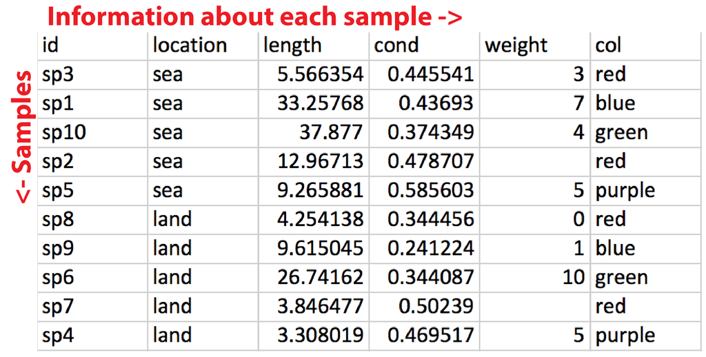

Figure 3: Data arrangement for R data frames. Samples should be placed along rows, observations about individual samples as columns.

## Importing data

Excel has become the standard data file format for biologists in Norway. Even though it is recommended to distribute data in open, rather than proprietary format, R can handle Excel files. Excel files can be directly imported to R using external packages, such as `openxlsx`

```r
library(openxlsx)
x <- openxlsx::read.xlsx("Data/1 example dataset.xlsx") # The :: explicitly specifies the package where the function is from
x
```

```
##      id location    length      cond weight    col
## 1   sp3      sea  5.566354 0.4455408      3    red
## 2   sp1      sea 33.257682 0.4369303      7   blue
## 3  sp10      sea 37.877004 0.3743490      4  green
## 4   sp2      sea 12.967129 0.4787072     NA    red
## 5   sp5      sea  9.265881 0.5856030      5 purple
## 6   sp8     land  4.254138 0.3444561      0    red
## 7   sp9     land  9.615045 0.2412235      1   blue
## 8   sp6     land 26.741619 0.3440867     10  green
## 9   sp7     land  3.846477 0.5023904     NA    red
## 10  sp4     land  3.308019 0.4695168      5 purple
```

R can [read data pretty much in any format](https://cran.r-project.org/doc/manuals/r-release/R-data.html). [This site](https://cran.r-project.org/web/packages/rio/vignettes/rio.html) might be a good place to start, when you need to import data in other formats than [Excel](https://stackoverflow.com/questions/6099243/read-an-excel-file-directly-from-a-r-script) or [text files](https://stat.ethz.ch/R-manual/R-devel/library/utils/html/read.table.html). Note that it is also possible to [read data from pdf files into R](https://cran.r-project.org/web/packages/pdftools/index.html), although the process might require a little bit of tweaking.

## Establishing an overview

The first thing to do with a data frame is to establish an overview of data. There are several helpful functions available for this purpose.

```r
summary(x) # summarizes the data frame
```

```
##       id              location             length            cond
##  Length:10          Length:10          Min.   : 3.308   Min.   :0.2412
##  Class :character   Class :character   1st Qu.: 4.582   1st Qu.:0.3519
##  Mode  :character   Mode  :character   Median : 9.440   Median :0.4412
##                                        Mean   :14.670   Mean   :0.4223
##                                        3rd Qu.:23.298   3rd Qu.:0.4764
##                                        Max.   :37.877   Max.   :0.5856
##
##      weight           col
##  Min.   : 0.000   Length:10
##  1st Qu.: 2.500   Class :character
##  Median : 4.500   Mode  :character
##  Mean   : 4.375
##  3rd Qu.: 5.500
##  Max.   :10.000
##  NA's   :2
```

```r
head(x) # shows 6 first rows of the data frame. Useful for real-world data
```

```
##     id location    length      cond weight    col
## 1  sp3      sea  5.566354 0.4455408      3    red
## 2  sp1      sea 33.257682 0.4369303      7   blue
## 3 sp10      sea 37.877004 0.3743490      4  green
## 4  sp2      sea 12.967129 0.4787072     NA    red
## 5  sp5      sea  9.265881 0.5856030      5 purple
## 6  sp8     land  4.254138 0.3444561      0    red
```

```r
tail(x) # shows 6 last rows of the data frame. Useful for real-world data
```

```
##     id location    length      cond weight    col
## 5  sp5      sea  9.265881 0.5856030      5 purple
## 6  sp8     land  4.254138 0.3444561      0    red
## 7  sp9     land  9.615045 0.2412235      1   blue
## 8  sp6     land 26.741619 0.3440867     10  green
## 9  sp7     land  3.846477 0.5023904     NA    red
## 10 sp4     land  3.308019 0.4695168      5 purple
```

```r
str(x) # Structure of the data frame showing column classes
```

```
## 'data.frame':    10 obs. of  6 variables:
##  $ id      : chr  "sp3" "sp1" "sp10" "sp2" ...
##  $ location: chr  "sea" "sea" "sea" "sea" ...
##  $ length  : num  5.57 33.26 37.88 12.97 9.27 ...
##  $ cond    : num  0.446 0.437 0.374 0.479 0.586 ...
##  $ weight  : num  3 7 4 NA 5 0 1 10 NA 5
##  $ col     : chr  "red" "blue" "green" "red" ...
```

## Subsetting and selecting data

“Subsetting” means selecting a part of data using a certain condition, while “selecting” means choosing rows or columns from a data frame. [Subsetting and selecting](http://www.statmethods.net/management/subset.html) work following the same principle by passing index vectors through the [subset operators](https://cran.r-project.org/web/packages/pdftools/index.html) `[ ]` and `$`.

**The `$` sign** selects a column from a data frame by name and returns it as a vector

```r
x$weight
```

```
##  [1]  3  7  4 NA  5  0  1 10 NA  5
```

**The `[ ]` operators** can be used to select rows and columns from a data frame. R always follows the **rows first, columns second** principle. Therefore subsetting is conducted using the formula: **OBJECT_NAME[ROWS, COLUMNS]**. In case you omit the comma (`,`) columns will be selected. For instance:

```r
x[1,] # select the first row of the data frame x as a data frame
```

```
##    id location   length      cond weight col
## 1 sp3      sea 5.566354 0.4455408      3 red
```

```r
x[,1] # select the first column of the data frame x as a vector
```

```
##  [1] "sp3"  "sp1"  "sp10" "sp2"  "sp5"  "sp8"  "sp9"  "sp6"  "sp7"  "sp4"
```

```r
x[1] # select the first column of the data frame x as a data frame
```

```
##      id
## 1   sp3
## 2   sp1
## 3  sp10
## 4   sp2
## 5   sp5
## 6   sp8
## 7   sp9
## 8   sp6
## 9   sp7
## 10  sp4
```

The `[ ]` operators accept **any vector that fits the data frame structure**. How to subset depends on the imagination of the user. In the following three sections, we go through common subsetting routines depending on vector type.

### Selecting and subsetting data with numeric vectors

Columns and rows can be selected by specifying their number in a vector

```r
x[c(1,3),] # 1st and 3rd row
```

```
##     id location    length      cond weight   col
## 1  sp3      sea  5.566354 0.4455408      3   red
## 3 sp10      sea 37.877004 0.3743490      4 green
```

```r
x[,c(1,3)] # 1st and 3rd column, equals to x[c(1,3)]
```

```
##      id    length
## 1   sp3  5.566354
## 2   sp1 33.257682
## 3  sp10 37.877004
## 4   sp2 12.967129
## 5   sp5  9.265881
## 6   sp8  4.254138
## 7   sp9  9.615045
## 8   sp6 26.741619
## 9   sp7  3.846477
## 10  sp4  3.308019
```

Selecting columns using column numbers is often the fastest way for data frames that do not change. The following function can be used to find corresponding column numbers:

```r
coln <- function (x) {
    y <- rbind(seq(1, ncol(x)))
    colnames(y) <- colnames(x)
    rownames(y) <- "col.number"
    return(y)
}
```

```r
coln(x)
```

```
##            id location length cond weight col
## col.number  1        2      3    4      5   6
```

Certain functions return index when a statement within the function holds. These functions can be used to subset data. In the example, we use [`grep` function](https://stat.ethz.ch/R-manual/R-devel/library/base/html/grep.html), which is a powerful regular expression tool.

```r
grep("re", x$col) # Index the col column vector elements that contain letters "re"
```

```
## [1] 1 3 4 6 8 9
```

```r
x[grep("re", x$col),] # Use the vector to subset data
```

```
##     id location    length      cond weight   col
## 1  sp3      sea  5.566354 0.4455408      3   red
## 3 sp10      sea 37.877004 0.3743490      4 green
## 4  sp2      sea 12.967129 0.4787072     NA   red
## 6  sp8     land  4.254138 0.3444561      0   red
## 8  sp6     land 26.741619 0.3440867     10 green
## 9  sp7     land  3.846477 0.5023904     NA   red
```

### Selecting and subsetting data with character vectors

Another way to select data is to use row and column names. Here we use a character vector.

```r
x[,c("id", "col")] # select id and col columns. Equal to x[c("id", "col")]
```

```
##      id    col
## 1   sp3    red
## 2   sp1   blue
## 3  sp10  green
## 4   sp2    red
## 5   sp5 purple
## 6   sp8    red
## 7   sp9   blue
## 8   sp6  green
## 9   sp7    red
## 10  sp4 purple
```

```r
x[c("1", "3"),] # select 1st and 3rd row a using character vector
```

```
##     id location    length      cond weight   col
## 1  sp3      sea  5.566354 0.4455408      3   red
## 3 sp10      sea 37.877004 0.3743490      4 green
```

### Selecting and subsetting data with logical vectors

Logical vectors can be used to select rows and columns. The length of the vector should be equal to data frame dimensions (i.e. if rows are selected, the number of rows, if columns, the number of columns). It is rarely reasonable to construct such vectors manually and this is where logical operators come in. In the following examples, we first construct logical vectors using logical operators and then apply these vectors to subset the data frame.

```r
colnames(x) %in% c("id", "cond") # logical vector to select id and cond columns from column names of x
```

```
## [1]  TRUE FALSE FALSE  TRUE FALSE FALSE
```

```r
x[,colnames(x) %in% c("id", "cond")] # the vector applied to x. You could omit the comma to get same result
```

```
##      id      cond
## 1   sp3 0.4455408
## 2   sp1 0.4369303
## 3  sp10 0.3743490
## 4   sp2 0.4787072
## 5   sp5 0.5856030
## 6   sp8 0.3444561
## 7   sp9 0.2412235
## 8   sp6 0.3440867
## 9   sp7 0.5023904
## 10  sp4 0.4695168
```

```r
x$location == "sea" # logical vector to subset samples with "sea" location
```

```
##  [1]  TRUE  TRUE  TRUE  TRUE  TRUE FALSE FALSE FALSE FALSE FALSE
```

```r
x[x$location == "sea",] # subsetting samples with "sea" location. It is not possible to omit the comma, because we apply the vector to rows
```

```
##     id location    length      cond weight    col
## 1  sp3      sea  5.566354 0.4455408      3    red
## 2  sp1      sea 33.257682 0.4369303      7   blue
## 3 sp10      sea 37.877004 0.3743490      4  green
## 4  sp2      sea 12.967129 0.4787072     NA    red
## 5  sp5      sea  9.265881 0.5856030      5 purple
```

```r
x$length > 10 # length column values that are greater than 10
```

```
##  [1] FALSE  TRUE  TRUE  TRUE FALSE FALSE FALSE  TRUE FALSE FALSE
```

```r
x[x$length > 10,] # subset samples that have length > 10
```

```
##     id location   length      cond weight   col
## 2  sp1      sea 33.25768 0.4369303      7  blue
## 3 sp10      sea 37.87700 0.3743490      4 green
## 4  sp2      sea 12.96713 0.4787072     NA   red
## 8  sp6     land 26.74162 0.3440867     10 green
```

### Subsetting using functions

There are several functions available for subsetting data. The most used one is perhaps [`subset`](https://stat.ethz.ch/R-manual/R-devel/library/base/html/subset.html)

```r
subset(x, col == "blue") # subset samples that have col of "blue"
```

```
##    id location    length      cond weight  col
## 2 sp1      sea 33.257682 0.4369303      7 blue
## 7 sp9     land  9.615045 0.2412235      1 blue
```

### Subsetting lists and passing object names

**Double `[[ ]]` operators** can be used to select data frame columns as vectors or list elements. This operator is useful when you want to pass object names to subset data to make your code shorter.

```r
value <- "length"
x[[value]]/2
```

```
##  [1]  2.783177 16.628841 18.938502  6.483565  4.632940  2.127069  4.807523
##  [8] 13.370809  1.923238  1.654009
```

## Column classes

As discussed earlier, there are several different types of vectors in R. When these vectors are bound to a data frame, their types are called “column classes”. The `str` function can be used to reveal the vector classes.

```r
str(x)
```

```
## 'data.frame':    10 obs. of  6 variables:
##  $ id      : chr  "sp3" "sp1" "sp10" "sp2" ...
##  $ location: chr  "sea" "sea" "sea" "sea" ...
##  $ length  : num  5.57 33.26 37.88 12.97 9.27 ...
##  $ cond    : num  0.446 0.437 0.374 0.479 0.586 ...
##  $ weight  : num  3 7 4 NA 5 0 1 10 NA 5
##  $ col     : chr  "red" "blue" "green" "red" ...
```

We see that “id”, “location” and “col” columns are characters, but for statistical analyses, we would like to have them as factors. **Changing the column class** is done by replacing the previous column class:

```r
x$id <- factor(x$id)
str(x$id)
```

```
##  Factor w/ 10 levels "sp1","sp10","sp2",..: 4 1 2 3 6 9 10 7 8 5
```

Changing **several columns at once** can be done using `rapply` or `lapply` functions:

```r
# lapply gives more control over which columns to change
x[c("location", "col")] <- lapply(x[c("location", "col")], function(k) factor(k))

str(x[c("location", "col")])
```

```
## 'data.frame':    10 obs. of  2 variables:
##  $ location: Factor w/ 2 levels "land","sea": 2 2 2 2 2 1 1 1 1 1
##  $ col     : Factor w/ 4 levels "blue","green",..: 4 1 2 4 3 4 1 2 4 3
```

```r
# rapply can be used to change all character columns at once
x <- rapply(object = x, f = factor, classes = "character", how = "replace")
```

`rapply` can also be used to round all numeric columns

```r
x <- rapply(object = x, f = round, classes = "numeric", how = "replace", digits = 2)

head(x)
```

```
##     id location length cond weight    col
## 1  sp3      sea   5.57 0.45      3    red
## 2  sp1      sea  33.26 0.44      7   blue
## 3 sp10      sea  37.88 0.37      4  green
## 4  sp2      sea  12.97 0.48     NA    red
## 5  sp5      sea   9.27 0.59      5 purple
## 6  sp8     land   4.25 0.34      0    red
```

**Factors can be ordered** to follow a certain order of the elements. This ordering is useful for **sorting data** frames and when you want to plot groups in a certain order. The ordering is done specifying the order of levels inside the `factor()` function using the `levels` argument and require you to specify all existing factor levels. Factor levels not specified will return `NA`s.

```r
factor(x$id, levels = paste0("sp", 1:10)) # defining id as ordered factor. paste0() creates a character vector specifying the order
```

```
##  [1] sp3  sp1  sp10 sp2  sp5  sp8  sp9  sp6  sp7  sp4
## Levels: sp1 sp2 sp3 sp4 sp5 sp6 sp7 sp8 sp9 sp10
```

```r
factor(x$id, levels = paste0("sp", 1:8)) # Doing it wrong. sp9 and sp10 turn to NAs
```

```
##  [1] sp3  sp1  <NA> sp2  sp5  sp8  <NA> sp6  sp7  sp4
## Levels: sp1 sp2 sp3 sp4 sp5 sp6 sp7 sp8
```

```r
x$id <- factor(x$id, levels = paste0("sp", 1:10)) # The newly ordered factor must be reassigned to take the place of the old one

x <- x[order(x$id),] # sort the data frame by id
rownames(x) <- 1:nrow(x) # rename rows to follow the order
x
```

```
##      id location length cond weight    col
## 1   sp1      sea  33.26 0.44      7   blue
## 2   sp2      sea  12.97 0.48     NA    red
## 3   sp3      sea   5.57 0.45      3    red
## 4   sp4     land   3.31 0.47      5 purple
## 5   sp5      sea   9.27 0.59      5 purple
## 6   sp6     land  26.74 0.34     10  green
## 7   sp7     land   3.85 0.50     NA    red
## 8   sp8     land   4.25 0.34      0    red
## 9   sp9     land   9.62 0.24      1   blue
## 10 sp10      sea  37.88 0.37      4  green
```

## Missing values

[Missing values](http://www.cookbook-r.com/Basics/Working_with_NULL_NA_and_NaN/) within vectors are represented by `NA` (not available), impossible values (for example dividing 0 by 0) are given as `NaN` (not a number) and values that do not exist are noted as `NULL`. **None of these are equal to 0**. Zero has a value (0), `NaN` has a value that is not a number, `NA` indicates that the value is missing, and `NULL` simply does not exist (well, at least R thinks so). Let’s make up some vectors to illustrate this

```r
k <- c(0,1,2,NA,NaN,NULL)
k # NULL is dropped, because it does not exist
```

```
## [1]   0   1   2  NA NaN
```

```r
3/k # dividing 3 by zero returns infinity, dividing by NA returns NA and dividing by NaN returns NaN
```

```
## [1] Inf 3.0 1.5  NA NaN
```

**Missing values can be replaced** by zeros and vice versa

```r
k[is.nan(k)] <- 0
k # NA still remains
```

```
## [1]  0  1  2 NA  0
```

```r
k <- c(0,1,2,NA,NaN,NULL)
k[is.na(k)] <- 0
k # NaN is understood as NA here
```

```
## [1] 0 1 2 0 0
```

```r
k[k == 0] <- NA
k
```

```
## [1] NA  1  2 NA NA
```

**Missing values can also be removed from a data frame** using the `na.omit` function

```r
na.omit(x)
```

```
##      id location length cond weight    col
## 1   sp1      sea  33.26 0.44      7   blue
## 3   sp3      sea   5.57 0.45      3    red
## 4   sp4     land   3.31 0.47      5 purple
## 5   sp5      sea   9.27 0.59      5 purple
## 6   sp6     land  26.74 0.34     10  green
## 8   sp8     land   4.25 0.34      0    red
## 9   sp9     land   9.62 0.24      1   blue
## 10 sp10      sea  37.88 0.37      4  green
```

## Descriptive statistics

Calculation of all kinds of descriptive statistics is rather easy in R. Most of the functions work on a vector level.

```r
mean(x$length) # average of 'length' column
```

```
## [1] 14.672
```

```r
sd(x$length) # standard deviation
```

```
## [1] 13.01724
```

```r
length(x$length) # length of the 'length' vector (n)
```

```
## [1] 10
```

```r
median(x$length) # sample median
```

```
## [1] 9.445
```

```r
se <- function(x) sd(x, na.rm = TRUE)/sqrt(sum(!is.na(x))) # standard error of mean
se(x$length)
```

```
## [1] 4.116414
```

**Missing values** (`NA`s) are included in calculations by default (returning NA). You’ll need to specify that NA’s should be ignored if you want to do calculations with them.

```r
mean(x$weight)
```

```
## [1] NA
```

```r
mean(x$weight, na.rm = TRUE)
```

```
## [1] 4.375
```

The `rowSums`, `colSums`, `rowMeans`, and `colMeans` functions are handy for getting row- and column sums and means from data frames and matrices.

```r
colSums(x[,3:5]) # Check also ?colMeans
```

```
## length   cond weight
## 146.72   4.22     NA
```

## Exersices

**E4.1a** Create a matrix with 3 columns and 3 rows using an integer vector from 1 to 9 arranged row-wise and select the second row from it.

**E4.1b** Multiply this row by 2 and replace it in the matrix

**E4.1c** Convert the matrix to a data.frame and make the first column to contain alphabets, which are defined by the numbers within the column vector (i.e. a = 1, …, 26 = z)

**4.1d** Convert the third column to Date-Time starting from 1st of January 2020.

**4.1e** Rename the columns according to their class

**4.1f** Select rows from the data.frame that contain even numbers following the order of alphabets

## Exporting data

R together with its extensions can write data to pretty much any imaginable format. The best format to save data for further use in R is the [`.Rdata` format](https://stat.ethz.ch/R-manual/R-devel/library/base/html/save.html) (`.rda` for short) for multiple objects or the [`.rds` format](https://stat.ethz.ch/R-manual/R-devel/library/base/html/readRDS.html) for single objects. Comma-separated text files (`.csv`) are recommended for sharing data with other users, but as discussed earlier, most biologists in Norway use Excel and saving Excel files directly from R is also possible.

```r
save(x, k, file = "Example data.rda") ## Save the objects you want to a R data file for later use
saveRDS(x, file = "Example data.rds") ## Save a single object as rds format
write.csv(x, file = "Example data.csv") ## Save a data frame as csv format

openxlsx::write.xlsx(x, file = "Example data.xlsx") ## Save a data frame as Excel format
```

# Answers to exercises

**E2.1**

```r
x <- c(TRUE, TRUE, FALSE, TRUE, FALSE, TRUE, TRUE, TRUE, TRUE, FALSE, TRUE, TRUE, TRUE, TRUE, TRUE, FALSE, FALSE, TRUE, FALSE, FALSE)

table(x)
```

```
## x
## FALSE  TRUE
##     7    13
```

```r
# OR

sum(x) # TRUEs
```

```
## [1] 13
```

```r
length(x) - sum(x) # FALSEs
```

```
## [1] 7
```

**E2.2**

```r
# POSIXct (Date-Time)
# numeric
# character
# numeric or integer
# factor
```

**E2.3**

```r
# a
(x <- letters)
```

```
##  [1] "a" "b" "c" "d" "e" "f" "g" "h" "i" "j" "k" "l" "m" "n" "o" "p" "q" "r" "s"
## [20] "t" "u" "v" "w" "x" "y" "z"
```

```r
# b
(x <- factor(x))
```

```
##  [1] a b c d e f g h i j k l m n o p q r s t u v w x y z
## Levels: a b c d e f g h i j k l m n o p q r s t u v w x y z
```

```r
#c
(x <- as.numeric(x))
```

```
##  [1]  1  2  3  4  5  6  7  8  9 10 11 12 13 14 15 16 17 18 19 20 21 22 23 24 25
## [26] 26
```

**E2.4**

```r
seq(0, 1000, length.out = 5)
```

```
## [1]    0  250  500  750 1000
```

**E2.5**

```r
10^seq(log10(1), log10(1000), length.out = 5)
```

```
## [1]    1.000000    5.623413   31.622777  177.827941 1000.000000
```

```r
# OR
10^seq(0, 3, length.out = 5)
```

```
## [1]    1.000000    5.623413   31.622777  177.827941 1000.000000
```

**E2.6**

```r
conv.fun <- function(x) as.numeric(as.character(x))

conv.fun(factor(c(3, 4, 10, 14.3)))
```

```
## [1]  3.0  4.0 10.0 14.3
```

**E4.1**

```r
# a

x <- matrix(1:9, ncol = 3, byrow = TRUE)
x[2,]
```

```
## [1] 4 5 6
```

```r
# b
x[2,] <- 2*x[2,]

#c
x <- as.data.frame(x)
x[,1] <- letters[x[,1]]

# d
x[,3] <- as.Date(x[,3], origin = "2020-01-01")

# e
names(x) <- unname(sapply(x, class))
x
```

```
##   character numeric       Date
## 1         a       2 2020-01-04
## 2         h      10 2020-01-13
## 3         g       8 2020-01-10
```

```r
# f
x[which(letters %in% x$character) %% 2 == 0,]
```

```
##   character numeric       Date
## 3         g       8 2020-01-10
```